# cutting the tree!

如果事先不知道几个组合适，怎么办？

根据dendrogram的高度来砍一刀，确定我们得到几个组？

先安装这个 install.packages(“dendextend”)

这里我们来借用dendrogram，确定一个最高的高度(h)，砍一刀，在这一刀下面，我们得以把观测样本分成不同的组。

我们会使用`dendextend`包里的`color_branches()`函数来将分组涂色。

- 注意：这个练习需要在本地电脑上完成！

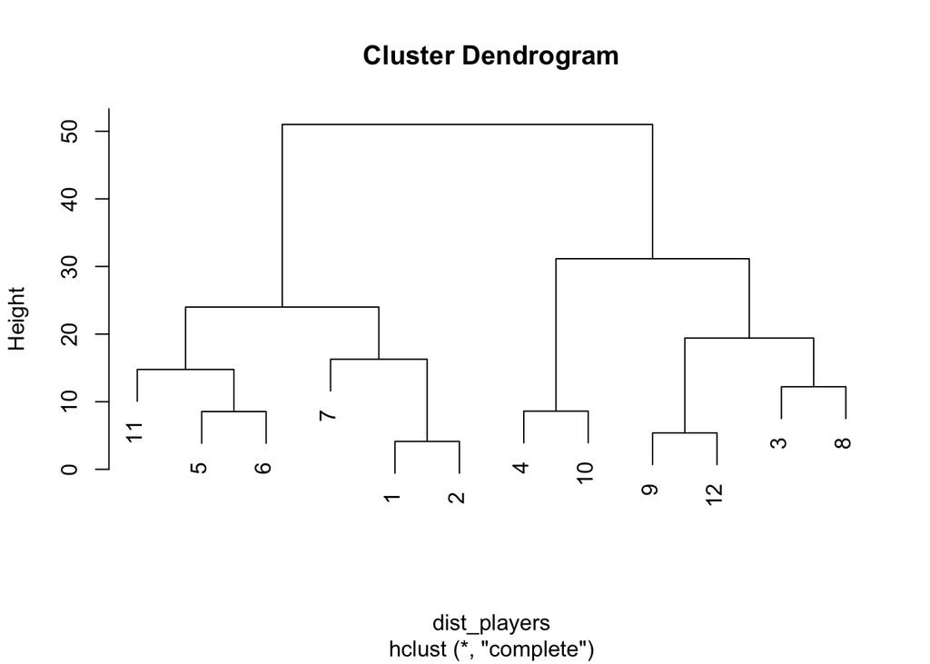

```r
lineup <- read.delim("https://www.dropbox.com/s/5olsxha9uam13uz/lineup.txt?dl=1")
library(ggplot2)
library(dplyr)
library(dendextend)
dist_players <- dist(lineup, method = 'euclidean')
hc_players <- hclust(dist_players, method = "complete")
plot(hc_players)
```

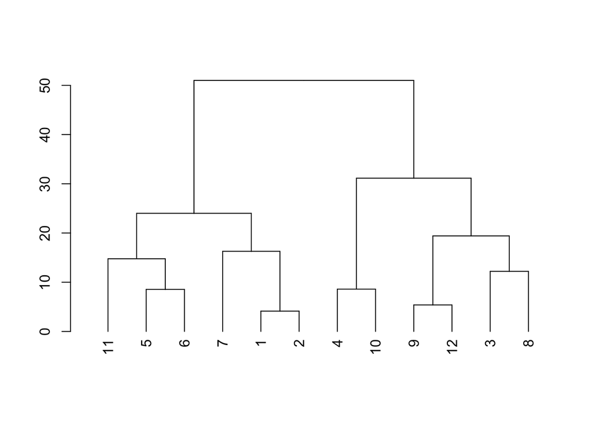

```r
# Create a dendrogram object from the hclust variable
dend_players <- as.dendrogram(hc_players)

# Plot the dendrogram
plot(dend_players)
```

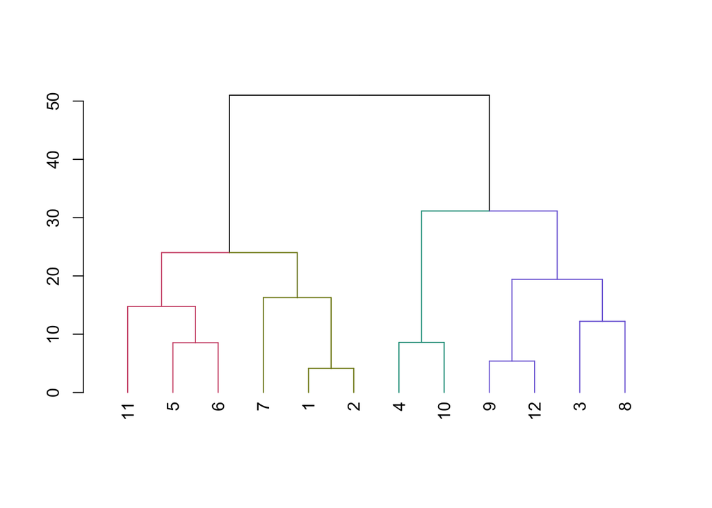

```r
# Color branches by cluster formed from the cut at a height of 20 & plot
dend_20 <- color_branches(dend_players, h = 20)

# Plot the dendrogram with clusters colored below height 20
plot(dend_20)
```

在h = 40处来一刀？

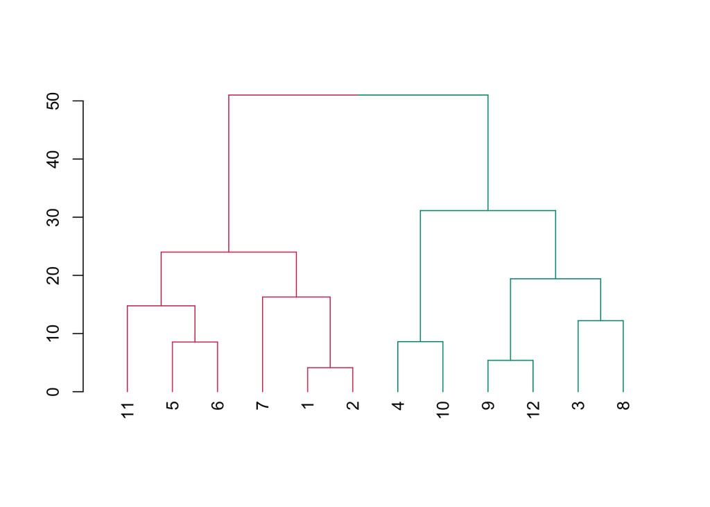

```r
# Color branches by cluster formed from the cut at a height of 40 & plot
dend_40 <- color_branches(dend_players, h = 40)

# Plot the dendrogram with clusters colored below height 40
plot(dend_40)
```

# 用k means 做聚类分析的原理：

1. 确定 k 个中心点。
2. 计算每个样本与中心点的距离。
3. 样本与哪个中心点距离近就被分配到哪个组。
4. 如此这般，我们把所有的样本分成了k组。
5. 然后我们找到每一个组的中心点。
6. 然后，我们再次计算每个样本与新的中心点的距离。
7. 根据每个样本点与新的中心点的距离，再次把样本分组。
8. 如此循环往复，直到再没有点改变它的分组。

# 用k means 做聚类分析的步骤：

1. 确定分组数量
- 如果事先知道要分几个组，例如k=2, 我们将数据传入 kmeans(lineup, centers = 2)，。
- 如果事先不知道要分几个组，我们可以从1到n（样本总量）都试一下，当然太大太接近n也没意义。一般地，我们可以使用 肘子法则（elbow rule: k 从小到大，依次取值，计算组内的方差的平均值，组分得越多，这个方差就越小，我们取那个使得组内方差急剧坠落的k值。然后将数据和得到的k值传入 kmeans(lineup, centers = 2)。
2. 从上述模型提取聚类结果。
3. 将该结果与原数据合并。
4. 分析每个组的特征。

# k means 实操练习1：

跟之前一样，我们用`lineup` 这个数据，里面是开场前两个球队球员的场中位置。 因为我们知道这是两个队的比赛，所以我们的K=2，没毛病。

我们的目标是，把球员各归各队各找各妈。

我们在`kmeans()` 这个函数中，将参数k的取值规定为2.

```r
lineup <- read.delim("https://www.dropbox.com/s/5olsxha9uam13uz/lineup.txt?dl=1")
```

```r
library(dplyr)
library(ggplot2)

# Build a kmeans model
model_km2 <- kmeans(lineup, centers = 2)

# Extract the cluster assignment vector from the kmeans model
clust_km2 <- model_km2$cluster

# Create a new dataframe appending the cluster assignment
lineup_km2 <- mutate(lineup, cluster = clust_km2)
```

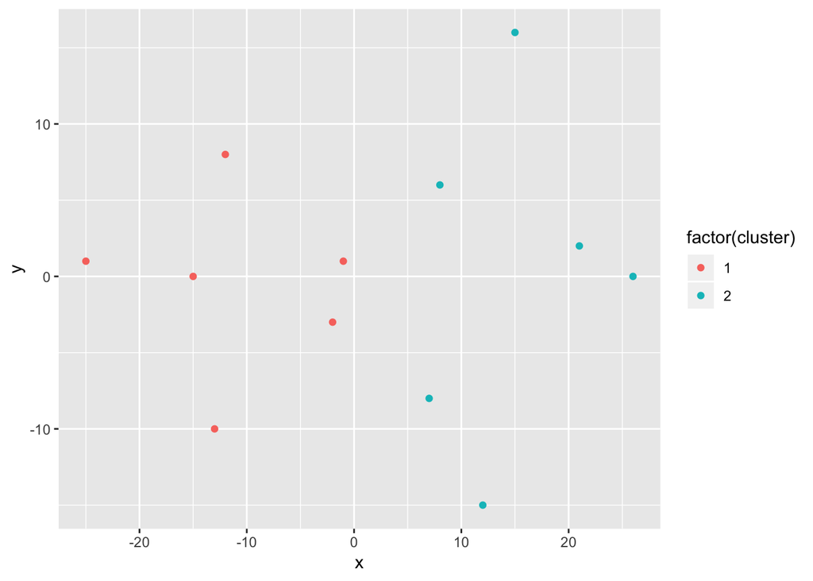

```r
# Plot the positions of the players and color them using their cluster
ggplot(lineup_km2, aes(x = x, y = y, color = factor(cluster))) +
  geom_point()
```